# An Introduction to dynamac: Dynamic Inferences (and Cointegration Testing) from Autoregressive Distributed Lag Models

Soren Jordan and Andrew Q. Philips

2020-04-02

Autoregressive distributed lag (ARDL) models are an integral part of estimating scientific processes over time. However, as we extend their usefulness by adding richness in dynamic specifications (through multiple lags of variables, either in levels or differences, or lags of the dependent variable), we begin to challenge our ability to draw meaningful inferences from coefficients alone. Variables may appear in multiple time periods, in multiple forms, and might even be filtered through lagged values of the dependent variable. Coefficients tell us about the immediate effect of some variable but have little to say about the long-run effect.

There is a better solution. Instead of performing intense operations to develop a closed-form or algebraic solution, we can rely on the power of computing to *simulate* the over-time response in the dependent variable of some model, given a corresponding change in an $x$ variable. We often call these “changes” in $x$ variables, and the associated response in the dependent variable $y$, a “counterfactual response” (a simulated response to a “shock” we control).

We illustrate the usefulness of these functions through example. After a brief discussion of the ARDL model in the general sense, we estimate a collection of these models and demonstrate both the challenges of the ARDL model in the abstract and the solutions of dynamac in particular.

## ARDL models generally

The ARDL model has a general form where $y$, modeled in levels or differences, is a function of itself (in lagged levels or differences), up to $k$ variables $x$, either in contemporaneous (same period, or appearing at time $t$) levels, lagged levels, contemporaneous differences, or lagged differences. Conventionally, the number of lags of the dependent variable in levels is counted by $p$, the number of lags of the dependent variable in differences is counted by $m$, the number of lags of the independent variables in levels is counted by $l$, and the number of lags of the independent variables in differences is counted by $q$ (note: $l$ and $q$ can begin at 0, i.e, contemporaneous effects appearing at time $t$).

The number of time periods of each variable can, theoretically, be quite large. Or, put differently, $p$, $m$, $l$, and $q$, especially $l$ and $q$, might be hard to account for. Analysts without strong theory about the nature of the effects often begin with restricting all but the contemporaneous and first lag of each series, or an ARDL model of the nature

$$y_t = \alpha_0 + \phi_1 y_{t-1} + \theta_{1,0} x_{1,t} + \theta_{1,1} x_{1,t-1} + \cdots + \theta_{k,0}x_{k,t} + \theta_{k,1}x_{k,t-1}+ \beta *T + \epsilon_t$$
where $\alpha_0$ is a constant and $\beta *T$ is a trend term. (The exact nature of this equation depends on whether $y$ is stationary or integrated, as well as if differences or lagged differences are entered into the model. But we will get to this below.)

It’s useful at this point to stop and think: if I have multiple lags of a variable $x$, and they are filtered through a lagged dependent variable $y_{t-1}$, it might be difficult to get a sense of the “total” effect of $x$ on $y$. This becomes more and more difficult as $x$ increases in lagged levels $l$ *and potentially also* lagged differences $q$. Our coefficient estimates, while estimated, are no longer as useful in direct interpretation. Put differently, the very flexibility of the ARDL model also undoes its usefulness in interpretation! So we might seek an alternative way of interpreting these models. dynamac provides a unified way of estimating ARDL models and interpreting their effects. It also provides a way of implementing a popular test for cointegration. We uncover these methods below.

## Estimating an ARDL model: best practices and dynamac

dynamac includes two datasets. We will use the Wright (2017) dataset on income inequality. We can look at the first few rows of this dataset

```r
library(dynamac)
head(ineq)
```

```
#>   year   mood urate concern demcontrol incshare10 csentiment incshare01
#> 1 1966 60.793   3.8   0.465          1     0.3198       97.0     0.0837
#> 2 1967 61.332   3.8   0.475          1     0.3205       94.7     0.0843
#> 3 1968 58.163   3.6   0.490          1     0.3198       94.2     0.0835
#> 4 1969 54.380   3.5   0.507          0     0.3182       90.3     0.0802
#> 5 1970 60.555   4.9   0.519          0     0.3151       75.8     0.0780
#> 6 1971 64.077   5.9   0.531          0     0.3175       80.6     0.0779
```

`concern` is public concern about income inequality; `incshare10` is the income share of the top ten percent; `urate` is the unemployment rate. Wright (2017) argues that concern about income inequality grows as inequality itself worsens and economic conditions deteriorate. A simple model, then, is that concern is a function of past values of itself, the level of income share held by the top ten percent, *changing* levels of income share held by the top ten percent, as well *changing* levels of unemployment in the short term.

$$\Delta Concern_t = \alpha_0 + \phi_1 Concern_{t-1} + \theta_1 Income Top 10_{t-1} + \beta_1 \Delta Income Top 10_t + \beta_2 \Delta Unemployment_t + \epsilon_t$$

where the residuals are white noise. Let’s develop the corresponding ARDL model using dynamac.

### Understanding our time series

Step 1 in any time series analysis is a visual inspection of the series coupled with formal tests of stationarity: whether the series has a constant mean, variance, and covariance over time (so that it reverts back to mean level), or if the series instead violates any of these three conditions. We advocate for using the urca package for this (Pfaff, Zivot, and Stigler 2016), which includes a variety of tools and tests. Simply plotting the series reveals the following:

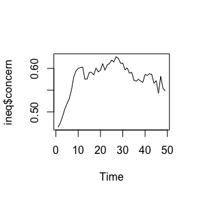

```r
library(urca)
ts.plot(ineq$concern)
```

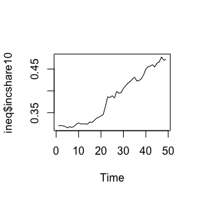

```r
ts.plot(ineq$incshare10)
```

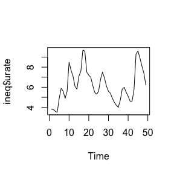

```r
ts.plot(ineq$urate)
```

None of the three series looks especially well-behaved. `concern` rose quickly and has been moving sluggishly since. `incshare10` has only grown over time, which cannot be mean-reverting (like a stationary series). `urate` experiences steep peaks and valleys with significant interludes in between. All three series look integrated. But we should be more discerning by using empirical tests, also included in urca. So we can execute the Augmented Dickey-Fuller (ADF) test, Phillips-Perron test, DF-GLS test, and KPSS test on each series. On `concern` this looks like

```r
summary(ur.df(ineq$concern, type = c("none"), lags = 1))
```

```
#>
#> ###############################################
#> # Augmented Dickey-Fuller Test Unit Root Test #
#> ###############################################
#>
#> Test regression none
#>
#>
#> Call:
#> lm(formula = z.diff ~ z.lag.1 - 1 + z.diff.lag)
#>
#> Residuals:
#>       Min        1Q    Median        3Q       Max
#> -0.029626 -0.006624  0.000511  0.011123  0.033842
#>
#> Coefficients:
#>             Estimate Std. Error t value Pr(>|t|)
#> z.lag.1     0.002474   0.003597   0.688    0.495
#> z.diff.lag -0.131523   0.148125  -0.888    0.379
#>
#> Residual standard error: 0.01422 on 45 degrees of freedom
#> Multiple R-squared:  0.0243, Adjusted R-squared:  -0.01907
#> F-statistic: 0.5603 on 2 and 45 DF,  p-value: 0.575
#>
#>
#> Value of test-statistic is: 0.6878
#>
#> Critical values for test statistics:
#>       1pct  5pct 10pct
#> tau1 -2.62 -1.95 -1.61
```

```r
summary(ur.pp(ineq$concern, type = c("Z-tau"), model = c("constant"), use.lag = 1))
```

```
#>
#> ##################################
#> # Phillips-Perron Unit Root Test #
#> ##################################
#>
#> Test regression with intercept
#>
#>
#> Call:
#> lm(formula = y ~ y.l1)
#>
#> Residuals:
#>       Min        1Q    Median        3Q       Max
#> -0.031791 -0.006041  0.000738  0.006481  0.031282
#>
#> Coefficients:
#>             Estimate Std. Error t value Pr(>|t|)
#> (Intercept)  0.09997    0.02946   3.393  0.00143 **
#> y.l1         0.83010    0.05085  16.324  < 2e-16 ***
#> ---
#> Signif. codes:  0 '***' 0.001 '**' 0.01 '*' 0.05 '.' 0.1 ' ' 1
#>
#> Residual standard error: 0.01274 on 46 degrees of freedom
#> Multiple R-squared:  0.8528, Adjusted R-squared:  0.8496
#> F-statistic: 266.5 on 1 and 46 DF,  p-value: < 2.2e-16
#>
#>
#> Value of test-statistic, type: Z-tau  is: -3.4373
#>
#>          aux. Z statistics
#> Z-tau-mu             3.496
#>
#> Critical values for Z statistics:
#>                      1pct     5pct     10pct
#> critical values -3.571174 -2.92277 -2.599003
```

```r
summary(ur.ers(ineq$concern, type = c("DF-GLS"), model = c("constant"), lag.max = 1))
```

```
#>
#> ###############################################
#> # Elliot, Rothenberg and Stock Unit Root Test #
#> ###############################################
#>
#> Test of type DF-GLS
#> detrending of series with intercept
#>
#>
#> Call:
#> lm(formula = dfgls.form, data = data.dfgls)
#>
#> Residuals:
#>       Min        1Q    Median        3Q       Max
#> -0.027024 -0.003352  0.003511  0.013156  0.036332
#>
#> Coefficients:
#>              Estimate Std. Error t value Pr(>|t|)
#> yd.lag       -0.02951    0.03305  -0.893    0.377
#> yd.diff.lag1 -0.10824    0.14675  -0.738    0.465
#>
#> Residual standard error: 0.01417 on 45 degrees of freedom
#> Multiple R-squared:  0.0312, Adjusted R-squared:  -0.01186
#> F-statistic: 0.7247 on 2 and 45 DF,  p-value: 0.4901
#>
#>
#> Value of test-statistic is: -0.8928
#>
#> Critical values of DF-GLS are:
#>                  1pct  5pct 10pct
#> critical values -2.61 -1.95 -1.62
```

```r
summary(ur.kpss(ineq$concern, type = c("mu"), use.lag = 1))
```

```
#>
#> #######################
#> # KPSS Unit Root Test #
#> #######################
#>
#> Test is of type: mu with 1 lags.
#>
#> Value of test-statistic is: 0.6415
#>
#> Critical value for a significance level of:
#>                 10pct  5pct 2.5pct  1pct
#> critical values 0.347 0.463  0.574 0.739
```

```r
summary(ur.df(diff(ineq$concern), type = c("none"), lags = 1))
summary(ur.pp(diff(ineq$concern), type = c("Z-tau"), model = c("constant"), use.lag = 1))
summary(ur.ers(diff(ineq$concern), type = c("DF-GLS"), model = c("constant"), lag.max = 1))
summary(ur.kpss(diff(ineq$concern), type = c("mu"), use.lag = 1))
```

Each of the above tests, when run, indicated that the differenced series of `concern` is stationary. Having gathered the basic information about the nature of the history of our variables, we might be itching to estimate some preliminary models. To this point, R hasn’t offered much in the way of improving beyond the basic `lm()` framework for using regression to estimate time series models in a consistent syntax. We elaborate on this problem and illustrate our solution, `dynardl`.

### Estimating ARDL models with `dynardl`

ARDL models are flexible, but their flexibility often results in variables of different lengths due to differencing and lagging. For instance, consider our simple model from above where `incshare10` appears as a first lag and a first difference, `urate` appears as a first difference, there is a lagged dependent variable, and `concern` is the dependent variable in differences. We can introduce a lag through the built-in `lshift` function in dynamac. The syntax is just `lshift(variable, num.lags)`, where `num.lags` is the number of periods for the variable to be lagged. We can also difference a series through `dshift`. The syntax is just `dshift(variable)` for a first difference. For instance,

```r
head(ineq$incshare10)
```

```
#> [1] 0.3198 0.3205 0.3198 0.3182 0.3151 0.3175
```

```r
head(lshift(ineq$incshare10, 1))
```

```
#> [1]     NA 0.3198 0.3205 0.3198 0.3182 0.3151
```

```r
head(dshift(ineq$incshare10))
```

```
#> [1]      NA  0.0007 -0.0007 -0.0016 -0.0031  0.0024
```

So the syntax for the simple model described would be easy to write. But notice the problem

```r
summary(lm(diff(ineq$concern) ~ lshift(ineq$concern, 1) + lshift(ineq$incshare10, 1) + dshift(ineq$incshare10) + dshift(ineq$urate)))
```

```
#> Error in model.frame.default(formula = diff(ineq$concern) ~ lshift(ineq$concern, : variable lengths differ (found for 'lshift(ineq$concern, 1)')
```

Introducing the lag changed the variable lengths, and we probably don’t want to have to think about time series operation in our model specification, anyway. Other software has unified this operation by introducing a common syntax, like d. for differencing and l. for lagging, or even l.d. for lag differences (what program could that be?). In R, though, it remains more of a nuisance than it should be. The `dynardl` function helps to remedy this challenge by encouraging the user only to think about model structure in exactly the way outlined above: which variables $x$ get lags $l$ and lagged differences $q$, etc. The function expects a basic formula of all the variables in the model, the data set (`data`), if there is one, then lagged levels (`lags`) and lagged differences (`lagdiffs`) as a list and differences (`diffs`) and contemporaneous levels (`levels`) as a vector. The sole exception is if the user wants to run the model in differences, s/he needs to specify `ec = TRUE` (in an effort to force us to think critically about the error-correction form of the model). For instance, our above model now becomes (ignoring the `simulate` option for now)

```r
dynardl(concern ~ incshare10 + urate, data = ineq,
        lags = list("concern" = 1, "incshare10" = 1),
        diffs = c("incshare10", "urate"),
        ec = TRUE, simulate = FALSE)
```

Purely hypothetically, if we wanted more lagged levels of `concern`, we would just change `1` to `c(1:5)` for lags at $t-1$ to $t-5$, or any other number of lags. If we wanted to include the first-difference of `urate` lagged at periods $t-1$ and $t-2$, we would now run

```r
dynardl(concern ~ incshare10 + urate, data = ineq,
        lags = list("concern" = 1, "incshare10" = 1),
        diffs = c("incshare10", "urate"),
        lagdiffs = list("urate" = c(1, 2)),
        ec = TRUE, simulate = FALSE)
```

If the variable can appear in multiple periods (`lags` and `lagdiffs`), it must be specified as a list. If it can only appear contemporaneously (`levels` and `diffs`), it must be specified as a vector. (The alternative was to specify `levels` through a `lag` at time 0: this did not seem practical.) We can also add or suppress a constant from the model by specifying `constant = TRUE/FALSE`, and we can do the same with a linear trend term with `trend = TRUE/FALSE` (by default, constants are included and trends are not).

The option `ec` specifies the nature of the dependent variable. If it is possibly error-correcting (`ec = TRUE`), it is run in differences, or period-over-period changes. If it is not (`ec = FALSE`), the dependent variable is run in levels.

### Cointegration testing using the ARDL-bounds procedure and `pssbounds`

The next step in ARDL-bounds is to estimate the error-correction form of the model. Two points are key: the independent variables that are potentially I(1) must be entered in levels, and the resulting residuals of the error-correction ARDL model must be white noise (random with no residual autocorrelation). Here, that means that we run our dependent variable in differences, we include the lagged levels of the dependent variable, we include the levels of the potentially cointegrating variable, `incshare10`, and the short-run effects of `urate` through differences. Returning to our model above, and using `dynardl`, this is now straightforward:

```r
res1 <- dynardl(concern ~ incshare10 + urate, data = ineq,
        lags = list("concern" = 1, "incshare10" = 1),
        diffs = c("incshare10", "urate"),
        ec = TRUE, simulate = FALSE)
```

```
#> [1] "Error correction (EC) specified; dependent variable to be run in differences."
```

```r
summary(res1)
```

```
#>
#> Call:
#> lm(formula = as.formula(paste(paste(dvnamelist), "~", paste(colnames(IVs),
#>     collapse = "+"), collapse = " ")))
#>
#> Residuals:
#>       Min        1Q    Median        3Q       Max
#> -0.025848 -0.005293  0.000692  0.006589  0.031563
#>
#> Coefficients:
#>                 Estimate Std. Error t value Pr(>|t|)
#> (Intercept)     0.122043   0.027967   4.364 7.87e-05 ***
#> l.1.concern    -0.167655   0.048701  -3.443   0.0013 **
#> d.1.incshare10  0.800585   0.296620   2.699   0.0099 **
#> d.1.urate       0.001118   0.001699   0.658   0.5138
#> l.1.incshare10 -0.068028   0.031834  -2.137   0.0383 *
#> ---
#> Signif. codes:  0 '***' 0.001 '**' 0.01 '*' 0.05 '.' 0.1 ' ' 1
#>
#> Residual standard error: 0.01169 on 43 degrees of freedom
#>   (1 observation deleted due to missingness)
#> Multiple R-squared:  0.3671, Adjusted R-squared:  0.3083
#> F-statistic: 6.236 on 4 and 43 DF,  p-value: 0.0004755
```

Next we need to ensure that the residuals from this model are white noise. To help with this, we also introduce `dynardl.auto.correlated`. This expects a `dynardl` model and implements a few white-noise-residual tests with readable output that reminds of the null hypotheses. Here, we just run

```r
dynardl.auto.correlated(res1)
```

```
#>
#>  ------------------------------------------------------
#>  Breusch-Godfrey LM Test
#>  Test statistic: 3.704
#>  p-value: 0.054
#>  H_0: no autocorrelation up to AR 1
#>
#>  ------------------------------------------------------
#>  Shapiro-Wilk Test for Normality
#>  Test statistic: 0.965
#>  p-value: 0.158
#>  H_0: residuals are distributed normal
#>
#>  ------------------------------------------------------
#>  Log-likelihood: 148.094
#>  AIC: -284.187
#>  BIC: -272.96
#>  Note: AIC and BIC calculated with k = 5 on T = 48 observations.
#>
#>  ------------------------------------------------------
#> Breusch-Godfrey test indicates we reject the null hypothesis of no autocorrelation at p < 0.10.
#>  Add lags to remove autocorrelation before running dynardl simulations.
```

At a reasonable level of significance ($p < 0.10$), the BG test indicates that we reject the null hypothesis of no autocorrelation in the residuals of the model in `res`. Philips (2018) indicates that the next step is to add lagged first-differences to our model. To add a lagged difference of $y$, we would run

```r
res2 <- dynardl(concern ~ incshare10 + urate, data = ineq,
        lags = list("concern" = 1, "incshare10" = 1),
        diffs = c("incshare10", "urate"),
        lagdiffs = list("concern" = 1),
        ec = TRUE, simulate = FALSE)
```

```
#> [1] "Error correction (EC) specified; dependent variable to be run in differences."
```

```r
summary(res2)
```

```
#>
#> Call:
#> lm(formula = as.formula(paste(paste(dvnamelist), "~", paste(colnames(IVs),
#>     collapse = "+"), collapse = " ")))
#>
#> Residuals:
#>       Min        1Q    Median        3Q       Max
#> -0.027161 -0.006046  0.001101  0.007727  0.026620
#>
#> Coefficients:
#>                 Estimate Std. Error t value Pr(>|t|)
#> (Intercept)     0.145837   0.031144   4.683 3.09e-05 ***
#> l.1.concern    -0.195132   0.052971  -3.684 0.000665 ***
#> ld.1.concern   -0.195748   0.131225  -1.492 0.143434
#> d.1.incshare10  0.679022   0.302936   2.241 0.030471 *
#> d.1.urate       0.001068   0.001665   0.641 0.524878
#> l.1.incshare10 -0.085775   0.032804  -2.615 0.012434 *
#> ---
#> Signif. codes:  0 '***' 0.001 '**' 0.01 '*' 0.05 '.' 0.1 ' ' 1
#>
#> Residual standard error: 0.01144 on 41 degrees of freedom
#>   (2 observations deleted due to missingness)
#> Multiple R-squared:  0.4174, Adjusted R-squared:  0.3464
#> F-statistic: 5.875 on 5 and 41 DF,  p-value: 0.0003507
```

and then again test for autocorrelation.

```r
dynardl.auto.correlated(res2)
```

```
#>
#>  ------------------------------------------------------
#>  Breusch-Godfrey LM Test
#>  Test statistic: 0.453
#>  p-value: 0.501
#>  H_0: no autocorrelation up to AR 1
#>
#>  ------------------------------------------------------
#>  Shapiro-Wilk Test for Normality
#>  Test statistic: 0.986
#>  p-value: 0.857
#>  H_0: residuals are distributed normal
#>
#>  ------------------------------------------------------
#>  Log-likelihood: 146.636
#>  AIC: -279.271
#>  BIC: -266.32
#>  Note: AIC and BIC calculated with k = 6 on T = 47 observations.
#>
#>  ------------------------------------------------------
```

```r
length(res2$model$residuals)
```

```
#> [1] 47
```

We can now be much more confident that there is no more autocorrelation in the residuals. At this point, we can execute the ARDL-bounds test procedure. We need a few pieces of information: the length of the time series, the $t$-statistic on the lagged dependent variable in the ARDL error-correction model, the “case” of the regression (a combination of whether the intercept, if any, and trend, if any, were restricted (Pesaran, Shin, and Smith 2001)), and the number of regressors $k$ appearing in first lags (NOT including the lagged dependent variable). We also need the number of observations in the model time series and the $F$-statistic on the restriction that the first lags of each of the variables in the model (including the lagged dependent variable) are jointly equal to zero.

From our regression, we know the $t$-statistic on the lagged dependent variable is -3.684 (just looking at the output). Additionally, we estimated a model with an unrestricted intercept and no trend, which happens to be case 3 (which we would know by referencing Pesaran, Shin, and Smith (2001)). There are $k = 1$ variables in first lags (`incshare10`, not including the LDV), and the number of `obs` in the model is 47 periods. We now only need the test of the restriction that the first lags are equal to zero. We can calculate this by hand through coefficient testing. If we have all of the coefficients, we just need to compare them to the set that are lagged levels:

```r
coef(res2$model)
```

```
#>    (Intercept)    l.1.concern   ld.1.concern d.1.incshare10      d.1.urate
#>    0.145837457   -0.195131693   -0.195747775    0.679022362    0.001067503
#> l.1.incshare10
#>   -0.085775490
```

```r
# The second coefficient is the LDV, and the last coefficient is also a first lag. So they're both restricted

B <- coef(res2$model)
V <- vcov(res2$model)

# tag restrictions on LDV and l.1.incshare10
R <- matrix(c(0, 1, 0, 0, 0, 0,
              0, 0, 0, 0, 0, 1), byrow = T, nrow = 2)
k.plus1 <- sum(R)

# Restriction is that it is equal to 0
q <- 0
fstat <- (1/k.plus1)*t(R%*%B-q)%*%solve(R%*%V%*%t(R))%*%(R%*%B-q)
fstat
```

```
#>          [,1]
#> [1,] 12.20351
```

To test for cointegration, we need special critical values for the F-test statistic. For this, we’re ready for `pssbounds`

```r
pssbounds(obs = 47, fstat = 12.20351, tstat = -3.684, case = 3, k = 1)
```

```
#>
#>  PESARAN, SHIN AND SMITH (2001) COINTEGRATION TEST
#>
#>  Observations: 47
#>  Number of Lagged Regressors (not including LDV) (k): 1
#>  Case: 3 (Unrestricted intercept; no trend)
#>
#>  ------------------------------------------------------
#>  -                       F-test                       -
#>  ------------------------------------------------------
#>                  <------- I(0) ------------ I(1) ----->
#>  10% critical value       4.19            4.94
#>  5% critical value        5.22            6.07
#>  1% critical value        7.56            8.69
#>
#>
#>  F-statistic = 12.204
#>  ------------------------------------------------------
#>  -                       t-test                       -
#>  ------------------------------------------------------
#>                  <------- I(0) ------------ I(1) ----->
#>  10% critical value       -2.57            -2.91
#>  5% critical value        -2.86            -3.22
#>  1% critical value        -3.43            -3.82
#>
#>
#>  t statistic = -3.684
#>  ------------------------------------------------------
#>
#>  t-statistic note: Small-sample critical values not provided for Case III. Asymptotic critical values used.
```

Finally, a payoff. The $t$-statistic and $F$-statistic are situated between special sample critical values. Depending on the level of significance that we preselected, these values offer a number of different conclusions. If the $F$-statistic exceeds the upper I(1) critical value, we may conclude cointegration. Thus, we can be confident that we have a well-specified model. If the F-statistic falls below the I(0) critical value, Pesaran, Shin, and Smith (2001) note that this indicates that all regressors are in fact stationary. Thus, cointegration cannot exist. If the F-statistic falls between the lower I(0) and upper I(1) critical values, the results are inconclusive. This means that cointegration may exist, but further testing and re-specification of the model is needed. Users that end up with these results are encouraged to see Philips (2018), who provides a strategy for dealing with this.

In our model here, since the value of the $F$-statistic exceeds the critical value at the upper I(1) bound of the test at the 5% level, we may conclude that Income Top 10 (the variable in the model in levels) and the dependent variable, Concern, are in a cointegrating relationship. This is furthered by the $t$-statistic of -3.684 falling below the 5% critical value for I(1). Thus, we can be confident both in our model specification and the unique, long-run relationship that exists between the two variables.

Calculating all of those values by hand was unnecessarily involved, especially since we know most of the values are saved post-estimation anyway. We’re further motivated not to have to reference the tables in Pesaran, Shin, and Smith (2001) for the case of the regression every time we run `pssbounds`. Thus, our preferred way of estimating the ARDL-bounds test is just by passing the error-correction model to `pssbounds`. In other words, the test is equivalent by just running

```r
pssbounds(res2)
```

```
#>
#>  PESARAN, SHIN AND SMITH (2001) COINTEGRATION TEST
#>
#>  Observations: 47
#>  Number of Lagged Regressors (not including LDV) (k): 1
#>  Case: 3 (Unrestricted intercept; no trend)
#>
#>  ------------------------------------------------------
#>  -                       F-test                       -
#>  ------------------------------------------------------
#>                  <------- I(0) ------------ I(1) ----->
#>  10% critical value       4.19            4.94
#>  5% critical value        5.22            6.07
#>  1% critical value        7.56            8.69
#>
#>
#>  F-statistic = 12.204
#>  ------------------------------------------------------
#>  -                       t-test                       -
#>  ------------------------------------------------------
#>                  <------- I(0) ------------ I(1) ----->
#>  10% critical value       -2.57            -2.91
#>  5% critical value        -2.86            -3.22
#>  1% critical value        -3.43            -3.82
#>
#>
#>  t statistic = -3.684
#>  ------------------------------------------------------
#>
#>  t-statistic note: Small-sample critical values not provided for Case III. Asymptotic critical values used.
```

Pesaran, Shin, and Smith (2001) also provide for testing that the intercept is also restricted, which they refer to as case 2. If we wanted to add this restriction to the test, we would use `restriction = TRUE` in `pssbounds`.

```r
pssbounds(res2, restriction = TRUE)
```

```
#>
#>  PESARAN, SHIN AND SMITH (2001) COINTEGRATION TEST
#>
#>  Observations: 47
#>  Number of Lagged Regressors (not including LDV) (k): 1
#>  Case: 2 (Intercept included in F-stat restriction; no trend)
#>
#>  ------------------------------------------------------
#>  -                       F-test                       -
#>  ------------------------------------------------------
#>                  <------- I(0) ------------ I(1) ----->
#>  10% critical value       3.18            3.65
#>  5% critical value        3.86            4.44
#>  1% critical value        5.50            6.24
#>
#>
#>  F-statistic = 8.137
#>
#>  ------------------------------------------------------
#>
#>  t-statistic note: Critical values do not currently exist for Case II.
```

Of course, users are encouraged to read Pesaran, Shin, and Smith (2001) and Philips (2018) for the implications of this test. We merely note that cases 2 and 4 accessible through `restriction = TRUE`. We also note that, for most users most of the time, case 3 will be the most common case (an unrestricted intercept and no trend).

Any `dynardl` object run in an error-correction format is available for `pssbounds` post-estimation. This, of course, is not meant to imply that all `dynardl` models are meant to be tested for cointegration. Stationary dependent variables cannot be cointegrated with other variables. As such, we would want to run those models in levels, with `EC = FALSE`. Like always, we point users to the importance of pre-regression testing of the nature of our variables, most specifically whether or not they are integrated. `dynardl` will attempt to be as helpful as possible, but in the end, it is up to the user to know which model is appropriate and to ensure that the model is specified correctly.

We had another motivation. `dynardl` + `pssbounds` are a powerful combination for estimating and testing for cointegration in a unified framework. But once we have tested for cointegration, we still want inferences about the nature of the effect of some $x$ variable on the dependent variable. And these inferences become much more difficult to obtain as our models increase in complexity. For instance, the very lagged difference of $y$ that we introduced to help purge autocorrelation from the model we just estimated made interpreting the coefficients from that model much less straightforward. In the next section, we elaborate on the ability of `dynardl` to provide these inferences through the process we outlined earlier: counterfactual simulation of a response to a shock in some $x$ variable. These inferences do not require anything beyond what we have already covered: a `dynardl` model and a theoretically interesting $x$ variable.